# Heurist Analysis

Johannes Burgers

10/30/2021

### Creating the data table

This process involves stitching the tables back together with a series of `left_joins` and then cleaning up the result.

# Playing with the data

### Does the gender of the author influence the gender of the characters?

```r
gender_authorship <- partition_narratives %>% #all of the data
  group_by(gender_author) %>% # Group by author
  filter(presentmentioned == "Present") %>% #Exclude characters who are only mentioned
  drop_na(gender) %>% #Drop empty gender fields
  count(gender) %>% #Count gender by type
  mutate(percent = round((n / sum(n) * 100), 2)) #Create percentage
```

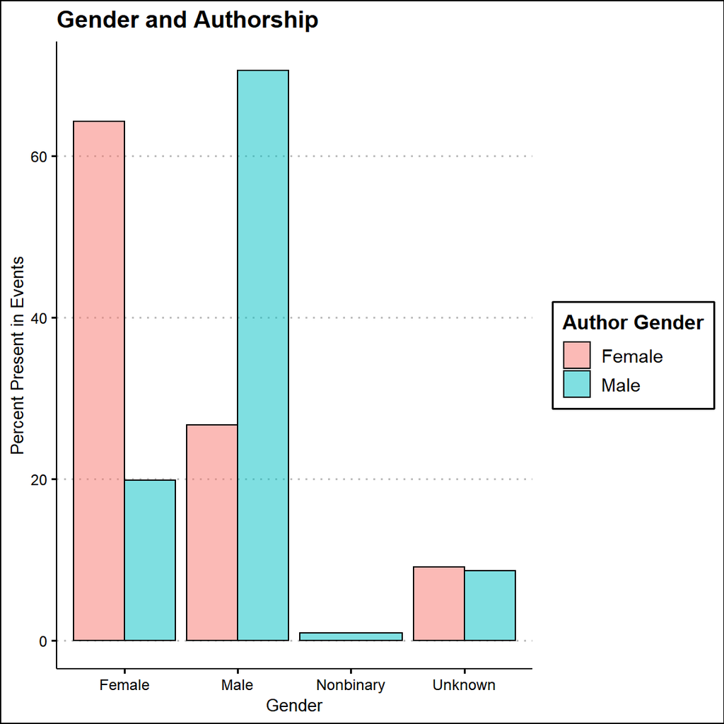

### What location has the most religious conflict?

```r
religion_places <-  partition_narratives %>%
  group_by(author_name) %>%
  mutate(location_religion = ifelse(
    str_detect(location_religion, "\\|") == TRUE,
    "Multi-faith",
    location_religion
  )) %>%
  filter(str_detect(conflict, "Religion")) %>%
  count(location_religion)
```

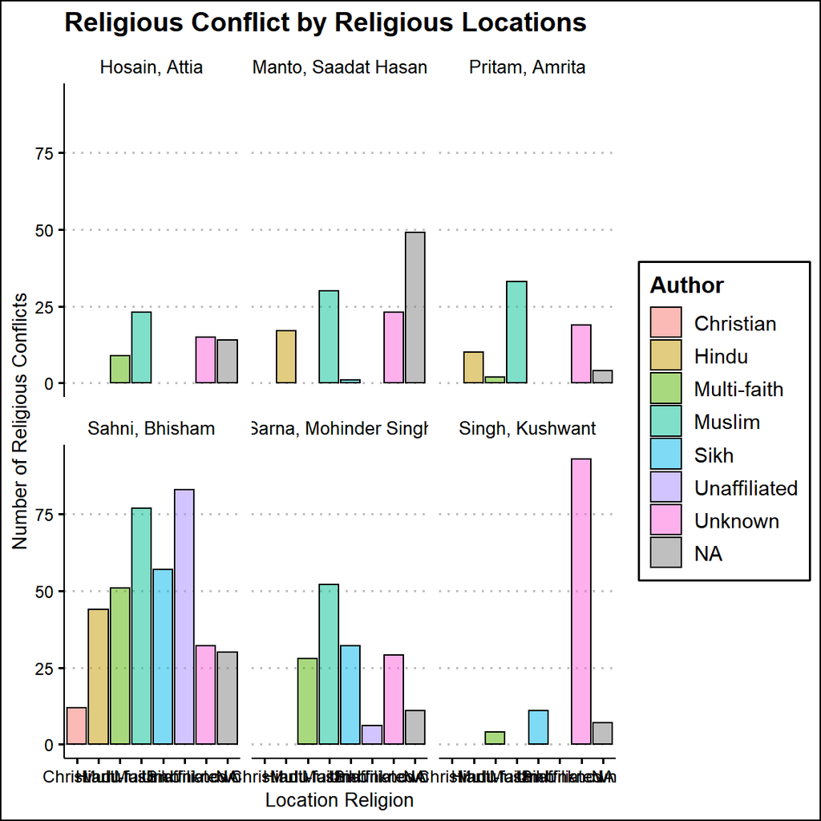

### Where do people die?

```r
death_places <- partition_narratives %>%
                group_by(place_name) %>%
                count(vitality) %>%
                drop_na(vitality)
```

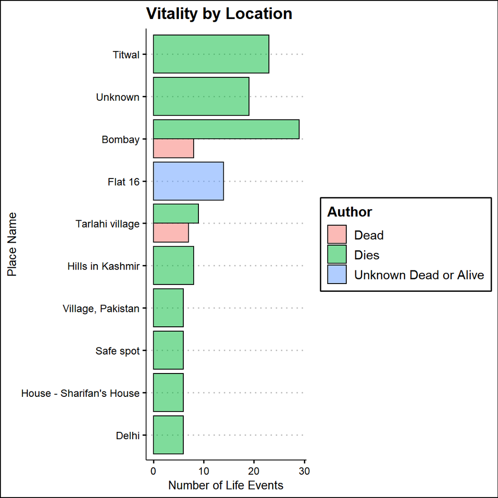

## Co-occurrence analysis

Co-occurrence allows you to determine the “rules of assembly” of the characters in the data set. That is, it determines if there is an underlying relationship between certain pairs of characters and if that relationship is positive (when one occurs the odds of another occurring are higher) or negative (when one occurs the odds of another occurring is lower). For example, one would expect that Male and Women of the same religion, and men of different religions might occur together, but a man and a woman from a different religion might be exceedingly rare.

You can use the code below to construct your own “species” by concatenating values across columns. In the example, I’ve combined gender and religion. One could equally well combine gender and conflict to see gender is statistically tied to what conflict. This is more accurate than doing a raw cross-tab because it takes into consideration how many of each quantity are in the data set. For example, there is only one main Jewish character in the text, but she always occurs with a Sikh. Her relationship is highly patterned.

### Run the co-occurrence

Run the co-occurrence analysis. Right now, this is set to the most computationally expensive settings. It will cast a matrix several columns wide. Please be patient, it might seem like nothing is happening, but you’ll eventually get a result.

```r
partition_gender_religion_cooccur <-
  cooccur(
    mat = partition_gender_religion,
    type = "spp_site",
    thresh = TRUE,
    spp_names = TRUE,
    true_rand_classifier = 0.1,
    prob = "comb",
    site_mask = NULL,
    only_effects = FALSE,
    eff_standard = FALSE,
    eff_matrix = FALSE
  )
```

### Co-occur object

The co-occur analysis will create an co-occur “object.” An object is a special data type that is composed of multiple-complex data types. All you really need to know is that you can’t view it as a table because it has a bunch of nested lists. To view different parts of it, you need to use the functions in the co-occur library. Each is described below.

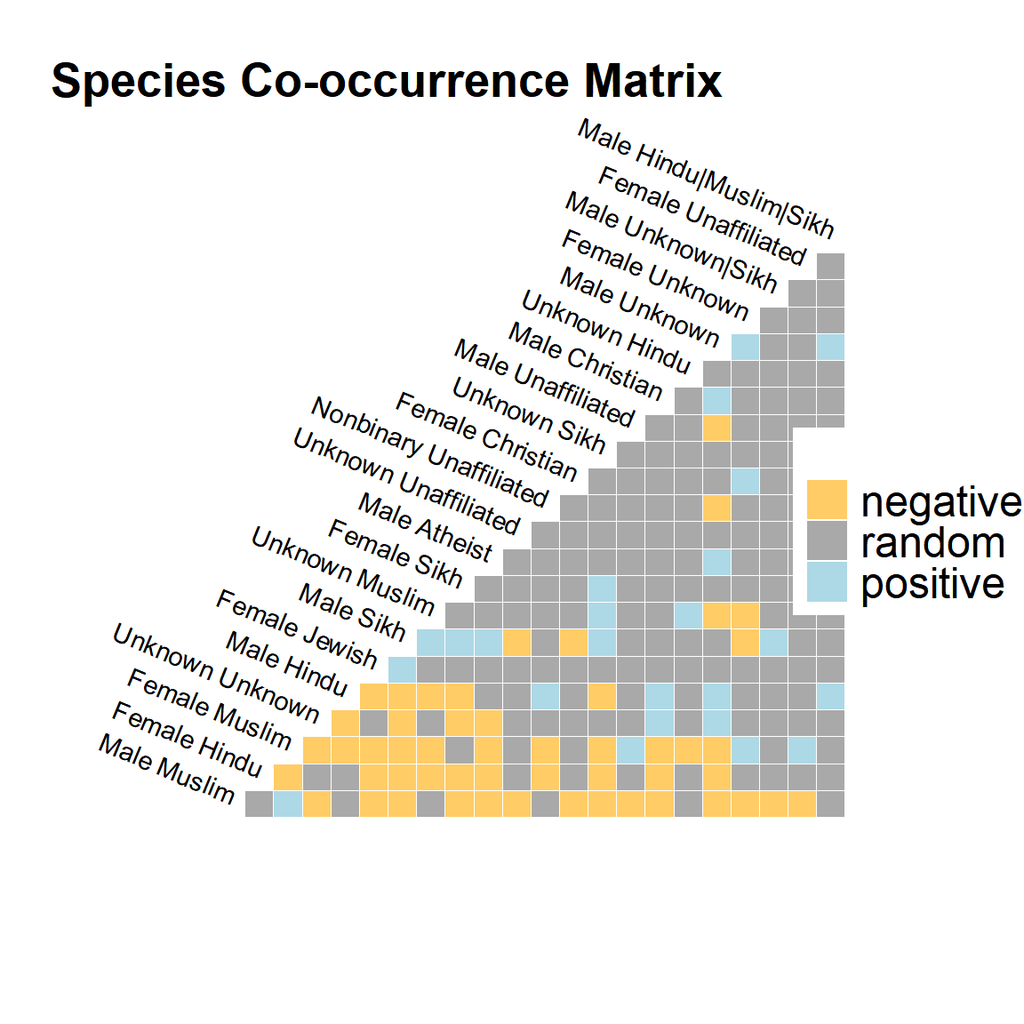

```
## Call:
## cooccur(mat = partition_gender_religion, type = "spp_site", thresh = TRUE,
##     spp_names = TRUE, true_rand_classifier = 0.1, prob = "comb",
##     site_mask = NULL, only_effects = FALSE, eff_standard = FALSE,
##     eff_matrix = FALSE)
##
## Of 666 species pair combinations, 510 pairs (76.58 %) were removed from the analysis because expected co-occurrence was < 1 and 156 pairs were analyzed
##
## Cooccurrence Summary:
```

```
##        Species          Sites       Positive       Negative         Random
##           37.0         1359.0           24.0           51.0           81.0
## Unclassifiable Non-random (%)
##            0.0           48.1
## attr(,"class")
## [1] "summary.cooccur"
```

| Co-occur Pairs | Co-occur Pairs pos | Co-occur Pairs neg | Co-occur Pairs rand | Co-occur Pairs num_pos | Co-occur Pairs num_neg | Co-occur Pairs num_rand | Co-occur Pairs sppname |
| --- | --- | --- | --- | --- | --- | --- | --- |
| 1 | 18.18 | 54.55 | 27.27 | 4 | 12 | 6 | Female Muslim |
| 10 | 28.57 | 38.1 | 33.33 | 6 | 8 | 7 | Male Sikh |
| 15 | 19.05 | 33.33 | 47.62 | 4 | 7 | 10 | Male Hindu |
| 19 | 10 | 20 | 70 | 1 | 2 | 7 | Female Christian |
| 20 | 25 | 25 | 50 | 3 | 3 | 6 | Male Christian |
| 21 | 10 | 10 | 80 | 1 | 1 | 8 | Unknown Hindu |
| 22 | 4.35 | 60.87 | 34.78 | 1 | 14 | 8 | Male Muslim |
| 23 | 0 | 47.62 | 52.38 | 0 | 10 | 11 | Female Hindu |
| 24 | 28.57 | 28.57 | 42.86 | 6 | 6 | 9 | Male Unknown |
| 2 | 10.53 | 31.58 | 57.89 | 2 | 6 | 11 | Unknown Unknown |
| 3 | 16.67 | 16.67 | 66.67 | 3 | 3 | 12 | Female Unknown |
| 4 | 18.75 | 31.25 | 50 | 3 | 5 | 8 | Unknown Muslim |
| 5 | 12.5 | 25 | 62.5 | 2 | 4 | 10 | Female Sikh |
| 6 | 25 | 33.33 | 41.67 | 3 | 4 | 5 | Unknown Sikh |
| 7 | 16.67 | 33.33 | 50 | 2 | 4 | 6 | Male Atheist |
| 8 | 0 | 25 | 75 | 0 | 2 | 6 | Unknown Unaffiliated |
| 9 | 14.29 | 14.29 | 71.43 | 1 | 1 | 5 | Male Unknown\|Sikh |
| 11 | 16.67 | 16.67 | 66.67 | 1 | 1 | 4 | Female Unaffiliated |
| 12 | 33.33 | 0 | 66.67 | 2 | 0 | 4 | Male Hindu\|Muslim\|Sikh |
| 13 | 10 | 30 | 60 | 1 | 3 | 6 | Nonbinary Unaffiliated |
| 14 | 0 | 0 | 100 | 0 | 0 | 1 | Male Hindu\|Sikh |
| 16 | 12.5 | 25 | 62.5 | 1 | 2 | 5 | Male Unaffiliated |
| 17 | 10 | 40 | 50 | 1 | 4 | 5 | Female Jewish |
| 18 | 0 | 0 | 100 | 0 | 0 | 2 | Nonbinary Unknown |

| Co-occur Probability Table | Co-occur Probability Table sp1 | Co-occur Probability Table sp2 | Co-occur Probability Table sp1_inc | Co-occur Probability Table sp2_inc | Co-occur Probability Table obs_cooccur | Co-occur Probability Table prob_cooccur | Co-occur Probability Table exp_cooccur | Co-occur Probability Table p_lt | Co-occur Probability Table p_gt | Co-occur Probability Table sp1_name | Co-occur Probability Table sp2_name |
| --- | --- | --- | --- | --- | --- | --- | --- | --- | --- | --- | --- |
| 1 | 1 | 2 | 377 | 316 | 27 | 0.065 | 87.7 | 0 | 1 | Female Muslim | Male Sikh |
| 2 | 1 | 3 | 377 | 262 | 51 | 0.053 | 72.7 | 0.00043 | 0.99977 | Female Muslim | Male Hindu |
| 3 | 1 | 4 | 377 | 20 | 6 | 0.004 | 5.5 | 0.69351 | 0.49477 | Female Muslim | Female Christian |
| 4 | 1 | 5 | 377 | 51 | 6 | 0.01 | 14.1 | 0.00471 | 0.99857 | Female Muslim | Male Christian |
| 5 | 1 | 6 | 377 | 20 | 0 | 0.004 | 5.5 | 0.00143 | 1 | Female Muslim | Unknown Hindu |
| 6 | 1 | 7 | 377 | 575 | 184 | 0.117 | 159.5 | 0.99888 | 0.00167 | Female Muslim | Male Muslim |
| 7 | 1 | 8 | 377 | 259 | 55 | 0.053 | 71.8 | 0.00514 | 0.99681 | Female Muslim | Female Hindu |
| 8 | 1 | 9 | 377 | 276 | 61 | 0.056 | 76.6 | 0.01071 | 0.99299 | Female Muslim | Male Unknown |
| 9 | 1 | 10 | 377 | 136 | 27 | 0.028 | 37.7 | 0.01735 | 0.99002 | Female Muslim | Unknown Unknown |
| 10 | 1 | 11 | 377 | 103 | 38 | 0.021 | 28.6 | 0.9869 | 0.02246 | Female Muslim | Female Unknown |
| 11 | 1 | 13 | 377 | 79 | 11 | 0.016 | 21.9 | 0.00222 | 0.99917 | Female Muslim | Unknown Muslim |
| 12 | 1 | 15 | 377 | 74 | 20 | 0.015 | 20.5 | 0.50408 | 0.6017 | Female Muslim | Female Sikh |
| 13 | 1 | 16 | 377 | 49 | 2 | 0.01 | 13.6 | 2e-05 | 1 | Female Muslim | Unknown Sikh |
| 14 | 1 | 17 | 377 | 51 | 2 | 0.01 | 14.1 | 1e-05 | 1 | Female Muslim | Male Atheist |
| 15 | 1 | 18 | 377 | 14 | 1 | 0.003 | 3.9 | 0.06646 | 0.98969 | Female Muslim | Unknown Unaffiliated |
| 16 | 1 | 19 | 377 | 12 | 2 | 0.002 | 3.3 | 0.30966 | 0.88746 | Female Muslim | Male Unknown\|Sikh |
| 17 | 1 | 20 | 377 | 6 | 6 | 0.001 | 1.7 | 1 | 0.00044 | Female Muslim | Female Unaffiliated |
| 18 | 1 | 24 | 377 | 8 | 0 | 0.002 | 2.2 | 0.07374 | 1 | Female Muslim | Male Hindu\|Muslim\|Sikh |
| 19 | 1 | 26 | 377 | 24 | 0 | 0.005 | 6.7 | 0.00038 | 1 | Female Muslim | Nonbinary Unaffiliated |
| 20 | 1 | 31 | 377 | 17 | 12 | 0.003 | 4.7 | 0.99996 | 0.00027 | Female Muslim | Male Unaffiliated |
| 21 | 1 | 32 | 377 | 21 | 0 | 0.004 | 5.8 | 0.00102 | 1 | Female Muslim | Female Jewish |
| 22 | 1 | 34 | 377 | 4 | 0 | 0.001 | 1.1 | 0.27216 | 1 | Female Muslim | Nonbinary Unknown |
| 23 | 2 | 3 | 316 | 262 | 42 | 0.045 | 60.9 | 0.00102 | 0.99944 | Male Sikh | Male Hindu |
| 24 | 2 | 4 | 316 | 20 | 0 | 0.003 | 4.7 | 0.00482 | 1 | Male Sikh | Female Christian |
| 25 | 2 | 5 | 316 | 51 | 11 | 0.009 | 11.9 | 0.46292 | 0.66854 | Male Sikh | Male Christian |
| 26 | 2 | 6 | 316 | 20 | 4 | 0.003 | 4.7 | 0.48708 | 0.71933 | Male Sikh | Unknown Hindu |
| 27 | 2 | 7 | 316 | 575 | 89 | 0.098 | 133.7 | 0 | 1 | Male Sikh | Male Muslim |
| 28 | 2 | 8 | 316 | 259 | 5 | 0.044 | 60.2 | 0 | 1 | Male Sikh | Female Hindu |
| 29 | 2 | 9 | 316 | 276 | 62 | 0.047 | 64.2 | 0.39757 | 0.66282 | Male Sikh | Male Unknown |
| 30 | 2 | 10 | 316 | 136 | 22 | 0.023 | 31.6 | 0.02256 | 0.98728 | Male Sikh | Unknown Unknown |

[output cut: 126 more lines]